```r
options(OutDec = ".")  # Asegurar punto decimal en este chunk

# Establecer semilla aleatoria
set.seed(sample(1:10000, 1))

# Variables de aleatorización para el formato de las opciones C y D
usar_fraccion_opcion_c <- sample(c(TRUE, FALSE), 1)
usar_fraccion_opcion_d <- sample(c(TRUE, FALSE), 1)

# Aleatorización del precio original
# Ampliamos la variedad de precios para aumentar la variabilidad
precios_base <- c(
  # Precios bajos (50.000 - 100.000)
  seq(50000, 100000, by=5000),
  # Precios medios (110.000 - 250.000)
  seq(110000, 250000, by=10000),
  # Precios altos (275.000 - 500.000)
  seq(275000, 500000, by=25000)
)
precio_original <- sample(precios_base, 1)

# Aleatorización del porcentaje de descuento
# Ampliamos la variedad de porcentajes para aumentar la variabilidad
porcentajes <- c(
  # Porcentajes comunes
  10, 15, 20, 25, 30, 33, 40, 50,
  # Porcentajes adicionales
  12, 18, 22, 28, 35, 38, 45, 48
)
porcentaje_descuento <- sample(porcentajes, 1)

# Aleatorización del contexto del problema
contextos_articulos <- list(
  c("un televisor", "televisor", "electrónico"),
  c("un celular", "celular", "electrónico"),
  c("un computador", "computador", "electrónico"),
  c("una lavadora", "lavadora", "electrodoméstico"),
  c("un refrigerador", "refrigerador", "electrodoméstico"),
  c("una bicicleta", "bicicleta", "artículo deportivo"),
  c("un sofá", "sofá", "mueble"),
  c("una mesa", "mesa", "mueble"),
  c("un vestido", "vestido", "prenda"),
  c("un traje", "traje", "prenda"),
  c("unos zapatos", "zapatos", "calzado"),
  c("un reloj", "reloj", "accesorio"),
  c("una joya", "joya", "accesorio"),
  c("un libro", "libro", "artículo educativo"),
  c("un boleto de avión", "boleto", "servicio")
)
contexto_seleccionado <- sample(contextos_articulos, 1)[[1]]
articulo <- contexto_seleccionado[1]
tipo_articulo <- contexto_seleccionado[2]
categoria <- contexto_seleccionado[3]

# Aleatorización de términos para el enunciado
terminos_ahorro <- c("ahorró", "economizó", "se descontó", "dejó de pagar", "redujo del pago")
termino_ahorro <- sample(terminos_ahorro, 1)

terminos_descuento <- c("descuento", "rebaja", "reducción", "oferta", "promoción")
termino_descuento <- sample(terminos_descuento, 1)

terminos_compra <- c("comprar", "adquirir", "obtener", "conseguir")
termino_compra <- sample(terminos_compra, 1)

terminos_costo <- c("costaba", "tenía un precio de", "valía", "estaba marcado en")
termino_costo <- sample(terminos_costo, 1)

terminos_procedimiento <- c("procedimientos", "métodos", "cálculos", "operaciones", "fórmulas")
termino_procedimiento <- sample(terminos_procedimiento, 1)

# Cálculos para las opciones
# Valor del descuento (ahorro)
valor_descuento <- precio_original * porcentaje_descuento / 100
# Precio final después del descuento
precio_final <- precio_original - valor_descuento
# Factor para el precio final (1 - porcentaje_descuento/100)
factor_precio_final <- 1 - porcentaje_descuento/100

# Generar las opciones de respuesta
# Opción A: Fracción equivalente al porcentaje × precio
fraccion <- switch(as.character(porcentaje_descuento),
                  "10" = "\\frac{1}{10}",
                  "12" = "\\frac{3}{25}",
                  "15" = "\\frac{3}{20}",
                  "18" = "\\frac{9}{50}",
                  "20" = "\\frac{1}{5}",
                  "22" = "\\frac{11}{50}",
                  "25" = "\\frac{1}{4}",
                  "28" = "\\frac{7}{25}",
                  "30" = "\\frac{3}{10}",
                  "33" = "\\frac{1}{3}",
                  "35" = "\\frac{7}{20}",
                  "38" = "\\frac{19}{50}",
                  "40" = "\\frac{2}{5}",
                  "45" = "\\frac{9}{20}",
                  "48" = "\\frac{12}{25}",
                  "50" = "\\frac{1}{2}")

# Fracción equivalente al factor (1 - porcentaje/100)
fraccion_factor <- switch(as.character(porcentaje_descuento),
                        "10" = "\\frac{9}{10}",
                        "12" = "\\frac{22}{25}",
                        "15" = "\\frac{17}{20}",
                        "18" = "\\frac{41}{50}",
                        "20" = "\\frac{4}{5}",
                        "22" = "\\frac{39}{50}",
                        "25" = "\\frac{3}{4}",
                        "28" = "\\frac{18}{25}",
                        "30" = "\\frac{7}{10}",
                        "33" = "\\frac{2}{3}",
                        "35" = "\\frac{13}{20}",
                        "38" = "\\frac{31}{50}",
                        "40" = "\\frac{3}{5}",
                        "45" = "\\frac{11}{20}",
                        "48" = "\\frac{13}{25}",
                        "50" = "\\frac{1}{2}")

opcion_a <- paste0(fraccion, " \\times ", format(precio_original, big.mark=".", decimal.mark=","))

# Opción B: Decimal equivalente al porcentaje × precio
decimal <- porcentaje_descuento / 100
opcion_b <- paste0(format(decimal, nsmall=2, decimal.mark=","), " \\times ", format(precio_original, big.mark=".", decimal.mark=","))

# Opción C: Fórmula estándar de porcentaje
opcion_c <- paste0("\\frac{", format(precio_original, big.mark=".", decimal.mark=","), " \\times ", porcentaje_descuento, "}{100}")

# Opción D: Factor para precio final × precio (NO calcula el ahorro)
opcion_d <- paste0(format(factor_precio_final, nsmall=2, decimal.mark=","), " \\times ", format(precio_original, big.mark=".", decimal.mark=","))

# Definir fracciones invertidas para cada porcentaje (para opciones incorrectas)
fraccion_invertida <- switch(as.character(porcentaje_descuento),
                           "10" = "\\frac{10}{1}",
                           "12" = "\\frac{25}{3}",
                           "15" = "\\frac{20}{3}",
                           "18" = "\\frac{50}{9}",
                           "20" = "\\frac{5}{1}",
                           "22" = "\\frac{50}{11}",
                           "25" = "\\frac{4}{1}",
                           "28" = "\\frac{25}{7}",
                           "30" = "\\frac{10}{3}",
                           "33" = "\\frac{3}{1}",
                           "35" = "\\frac{20}{7}",
                           "38" = "\\frac{50}{19}",
                           "40" = "\\frac{5}{2}",
                           "45" = "\\frac{20}{9}",
                           "48" = "\\frac{25}{12}",
                           "50" = "\\frac{2}{1}")

# Elegir aleatoriamente cuál opción (A, B o C) será la correcta
indice_correcto <- sample(1:3, 1)

# Generar opciones según el índice correcto
# Opción A
if (indice_correcto == 1) {
  # Opción A correcta: Fracción correcta × precio
  opcion_a <- paste0(fraccion, " \\cdot (", format(precio_original, big.mark=".", decimal.mark=","), ")")
} else {
  # Opción A incorrecta: Fracción invertida × precio
  opcion_a <- paste0(fraccion_invertida, " \\cdot (", format(precio_original, big.mark=".", decimal.mark=","), ")")
}

# Opción B
if (indice_correcto == 2) {
  # Opción B correcta: precio × porcentaje ÷ 100
  opcion_b <- paste0(format(precio_original, big.mark=".", decimal.mark=","), " \\times ", porcentaje_descuento, "\\%", " \\div 100")
} else {
  # Opción B incorrecta: precio × porcentaje × 100
  opcion_b <- paste0(format(precio_original, big.mark=".", decimal.mark=","), " \\times ", porcentaje_descuento, "\\%", " \\times 100")
}

# Opción C
if (indice_correcto == 3) {
  # Opción C correcta: precio × porcentaje / 100
  if (usar_fraccion_opcion_c) {
    opcion_c <- paste0("\\frac{", porcentaje_descuento, "}{100}", " \\times ", format(precio_original, big.mark=".", decimal.mark=","))
  } else {
    opcion_c <- paste0("\\frac{", format(precio_original, big.mark=".", decimal.mark=","), " \\times ", porcentaje_descuento, "}{100}")
  }
} else {
  # Opción C incorrecta: precio × 100 / porcentaje
  opcion_c <- paste0("\\frac{", format(precio_original, big.mark=".", decimal.mark=","), " \\times 100}{", porcentaje_descuento, "}")
}

# Opción D: Siempre incorrecta, calcula el precio final
if (usar_fraccion_opcion_d) {
  opcion_d <- paste0(fraccion_factor, " \\cdot ", format(precio_original, big.mark=".", decimal.mark=","))
} else {
  opcion_d <- paste0(format(factor_precio_final, nsmall=2, decimal.mark=","), " \\cdot ", format(precio_original, big.mark=".", decimal.mark=","))
}

# Verificación adicional para garantizar que todas las opciones sean diferentes
# Si aún hay opciones duplicadas, añadir elementos decorativos adicionales
if (length(unique(c(opcion_a, opcion_b, opcion_c, opcion_d))) < 4) {
  # Añadir un identificador único a cada opción
  opcion_a <- paste0("\\textrm{A: }", opcion_a)
  opcion_b <- paste0("\\textrm{B: }", opcion_b)
  opcion_c <- paste0("\\textrm{C: }", opcion_c)
  opcion_d <- paste0("\\textrm{D: }", opcion_d)
}

# Verificación final
opciones_temp <- c(opcion_a, opcion_b, opcion_c, opcion_d)
if (length(unique(opciones_temp)) < 4) {
  # Si todavía hay duplicados, añadir espacios adicionales para hacerlos diferentes
  opcion_a <- paste0(opcion_a, "\\,")
  opcion_b <- paste0(opcion_b, "\\;")
  opcion_c <- paste0(opcion_c, "\\!")
  opcion_d <- paste0(opcion_d, "\\:")
}

# Crear vector con todas las opciones
opciones <- c(opcion_a, opcion_b, opcion_c, opcion_d)

# Crear el vector de solución para r-exams (1 para la respuesta correcta, 0 para las incorrectas)
# El índice correcto ya fue seleccionado aleatoriamente en la generación de opciones
solucion <- rep(0, 4)
solucion[indice_correcto] <- 1

# Formatear valores para Python
precio_original_formateado <- gsub("\\.", ",", format(precio_original, big.mark="."))
valor_descuento_formateado <- gsub("\\.", ",", format(round(valor_descuento), big.mark="."))

# Guardar variables en el entorno global para que sean accesibles en las pruebas
.GlobalEnv$precio_original_global <- precio_original
.GlobalEnv$porcentaje_descuento_global <- porcentaje_descuento
.GlobalEnv$valor_descuento_global <- valor_descuento
.GlobalEnv$precio_final_global <- precio_final
.GlobalEnv$factor_precio_final_global <- factor_precio_final
.GlobalEnv$decimal_global <- decimal
.GlobalEnv$fraccion_global <- fraccion
.GlobalEnv$fraccion_factor_global <- fraccion_factor
.GlobalEnv$opciones_global <- opciones
.GlobalEnv$indice_correcto_global <- indice_correcto
.GlobalEnv$solucion_global <- solucion
.GlobalEnv$articulo_global <- articulo
.GlobalEnv$termino_ahorro_global <- termino_ahorro
.GlobalEnv$termino_descuento_global <- termino_descuento
.GlobalEnv$termino_compra_global <- termino_compra
.GlobalEnv$termino_costo_global <- termino_costo
.GlobalEnv$termino_procedimiento_global <- termino_procedimiento
.GlobalEnv$usar_fraccion_opcion_c <- usar_fraccion_opcion_c
.GlobalEnv$usar_fraccion_opcion_d <- usar_fraccion_opcion_d
```

```r
options(OutDec = ".")  # Asegurar punto decimal en este chunk

# Crear un archivo Python temporal con el código
archivo_python <- tempfile(fileext = ".py")

# Preparar el código Python sin usar sprintf para evitar problemas con los marcadores %
codigo_python <- paste0('
import matplotlib
matplotlib.use("Agg")  # Usar backend no interactivo
import matplotlib.pyplot as plt
import numpy as np
from matplotlib.patches import Rectangle
import matplotlib.patheffects as path_effects

# Configuración de colores
color_precio_original = "#3498db"  # Azul
color_descuento = "#e74c3c"        # Rojo
color_precio_final = "#2ecc71"     # Verde

# Crear figura
fig, ax = plt.subplots(figsize=(8, 4))

# Datos para la visualización
precio_original = ', precio_original, '
porcentaje_descuento = ', porcentaje_descuento, '
valor_descuento = precio_original * porcentaje_descuento / 100
precio_final = precio_original - valor_descuento

# Crear barras para representar los precios
bar_width = 0.4
x_pos = [0, 1]

# Barra para precio original
ax.bar(x_pos[0], precio_original, bar_width, color=color_precio_original,
       edgecolor="black", linewidth=1.5, label="Precio original")

# Barra para precio final y descuento
ax.bar(x_pos[1], precio_final, bar_width, color=color_precio_final,
       edgecolor="black", linewidth=1.5, label="Precio final")
ax.bar(x_pos[1], valor_descuento, bar_width, bottom=precio_final,
       color=color_descuento, edgecolor="black", linewidth=1.5,
       hatch="///", label="Descuento (', porcentaje_descuento, '%)")

# Añadir etiquetas con valores
def add_value_label(x, y, value, color="black", fontsize=10, fontweight="bold"):
    text = ax.text(x, y, f"${value:,.0f}".replace(",", "."),
                  ha="center", va="bottom", fontsize=fontsize, fontweight=fontweight)
    text.set_path_effects([path_effects.withStroke(linewidth=3, foreground="white")])
    return text

# Etiqueta para precio original
add_value_label(x_pos[0], precio_original, precio_original)

# Etiqueta para precio final
add_value_label(x_pos[1], precio_final/2, precio_final)

# Etiqueta para descuento
add_value_label(x_pos[1], precio_final + valor_descuento/2, valor_descuento)

# Añadir porcentaje de descuento
ax.text(x_pos[1] + 0.25, precio_final + valor_descuento/2,
       f"{porcentaje_descuento}%", ha="left", va="center",
       fontsize=12, fontweight="bold", color=color_descuento)

# Configurar ejes
ax.set_xticks(x_pos)
ax.set_xticklabels(["Precio original", "Precio con descuento"], fontsize=10, fontweight="bold")
ax.set_ylabel("Precio ($)", fontsize=10, fontweight="bold")
ax.set_title("Representación del descuento", fontsize=14, fontweight="bold", pad=15)

# Eliminar bordes superiores y derechos
ax.spines["top"].set_visible(False)
ax.spines["right"].set_visible(False)

# Añadir leyenda
ax.legend(loc="upper center", bbox_to_anchor=(0.5, -0.15), ncol=3, frameon=False, fontsize=9)

# Crear una imagen separada para las fórmulas
fig_formula = plt.figure(figsize=(6, 1.2))
plt.axis("off")
plt.text(0.5, 0.7, "Ahorro = Precio original × Porcentaje de descuento ÷ 100",
         ha="center", va="center", fontsize=10)

# Formatear los valores directamente en Python sin el símbolo $
precio_formateado = "{:,.0f}".format(precio_original).replace(",", ".")
descuento_formateado = "{:,.0f}".format(valor_descuento).replace(",", ".")

# Usar formato simple sin símbolos $ para evitar problemas
ejemplo_texto = "Ejemplo: " + precio_formateado + " × " + str(porcentaje_descuento) + "% ÷ 100 = " + descuento_formateado
plt.text(0.5, 0.3, ejemplo_texto,
         ha="center", va="center", fontsize=10)

plt.tight_layout()
plt.savefig("formula_descuento.png", dpi=150, bbox_inches="tight", transparent=True)
plt.close(fig_formula)

# Ajustar diseño
plt.tight_layout(rect=[0, 0.05, 1, 0.95])

# Guardar en múltiples formatos para asegurar compatibilidad
plt.savefig("visualizacion_descuento.png", dpi=150, bbox_inches="tight", format="png")
plt.savefig("visualizacion_descuento.pdf", dpi=150, bbox_inches="tight", format="pdf")
plt.close()
')

# Escribir el código Python en el archivo temporal
writeLines(codigo_python, archivo_python)

# Ejecutar el archivo Python
py_run_file(archivo_python)

# Eliminar el archivo temporal
unlink(archivo_python)
```

# Question

Se quiere saber cuánto dinero ahorró una persona al conseguir un sofá que valía $140.000 y tenía un(a) promoción del 28%.

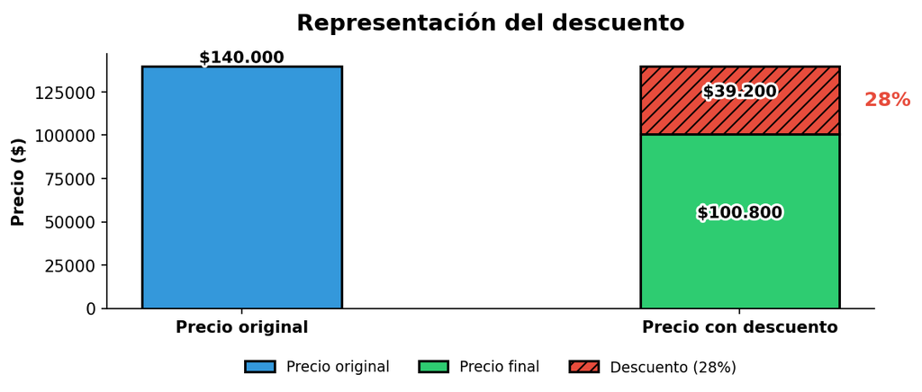

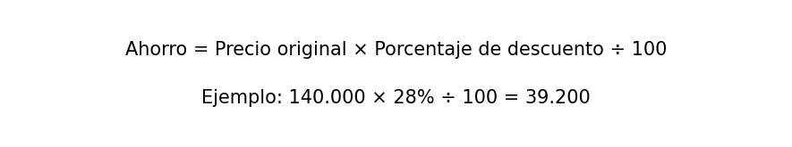

¿Cuál de las siguientes procedimientos permite calcular este valor?

## Answerlist

- $\frac{25}{7} \cdot (140.000)$
- $140.000 \times 28\% \times 100$
- $\frac{140.000 \times 28}{100}$
- $\frac{18}{25} \cdot 140.000$

# Solution

Para resolver este problema, debemos analizar cada uno de los procedimientos propuestos y determinar cuál permite calcular correctamente el ahorro obtenido al aplicar un descuento del 28% a un artículo que cuesta $140.000.

### Datos del problema:

- Precio original: $140.000
- Porcentaje de descuento: 28%
- Valor del descuento (ahorro): $39.200 (calculado como 28% de $140.000)

### Análisis de cada opción:

#### * Opción: $\frac{25}{7} \cdot (140.000)$

Esta opción utiliza una fracción invertida, lo que produce un resultado incorrecto. La fracción correcta para 28% sería $\frac{7}{25}$, pero aquí se usa $\frac{25}{7}$. Al multiplicar esta fracción invertida por el precio original, obtenemos un valor incorrecto: $\frac{25}{7} \times 140.000 = 500.000$. Este resultado no corresponde al ahorro de $39.200$. **Este procedimiento NO permite calcular correctamente el ahorro.**

#### * Opción: $140.000 \times 28\% \times 100$

Esta opción contiene un error común: multiplicar por 100 en lugar de dividir por 100. La operación correcta sería dividir por 100, pero aquí se multiplica por 100: $140.000 \times 28\% \times 100 = 392.000.000$. Este resultado es 10,000 veces mayor que el ahorro real de $39.200$. **Este procedimiento NO permite calcular correctamente el ahorro.**

#### * Opción: $\frac{140.000 \times 28}{100}$

Esta opción representa la fórmula estándar para calcular un porcentaje del precio original: $\frac{140.000 \times 28}{100} = 39.200$. **Este procedimiento SÍ permite calcular correctamente el ahorro.**

#### * Opción: $\frac{18}{25} \cdot 140.000$

Esta opción representa el factor para calcular el precio final (después del descuento) multiplicado por el precio original. $0,72$ es equivalente a $(1 - 28/100)$. Al multiplicar este factor por el precio original, obtenemos el precio final después del descuento: $0,72 \times 140.000 = 100.800$. Este cálculo nos da el precio final después del descuento, NO el ahorro. **Este procedimiento NO permite calcular correctamente el ahorro.**

### Verificación matemática:

Para calcular correctamente el ahorro en un descuento porcentual, debemos multiplicar el precio original por el porcentaje de descuento y dividir por 100:

Ahorro = Precio original × Porcentaje de descuento ÷ 100 Ahorro = $140.000 × 28% ÷ 100 = $39.200

### Conclusión:

Después de analizar todas las opciones, solo la opción C permite calcular correctamente el ahorro obtenido en la compra. Las demás opciones contienen errores matemáticos o calculan valores diferentes al ahorro.

## Answerlist

- Falso
- Falso
- Verdadero
- Falso

# Meta-information

exname: descuentos_porcentajes extype: schoice exsolution: 0010 exshuffle: TRUE exsection: Aritmética|Porcentajes|Descuentos